# Datos de Eurostat con R

Programación y manejo de datos con R (Slides 04-B)

Pedro J. Pérez

pedro.j.perez@uv.es

## ¿Qué es Eurostat?

- [Eurostat](https://ec.europa.eu/eurostat) es la oficina estadística de la Unión Europea. Depende de la Comisión Europea y está en Luxemburgo
- No hace encuestas: recoge los datos de los institutos de estadística de cada país (en España, el INE) y los **armoniza**
- Tiene datos de los 27 países de la UE, y muchas veces también de la EFTA (Noruega, Suiza, Islandia), de los países candidatos y de las regiones (NUTS)

fuente a la que ir cuando queremos comparar países o regiones europeas

- el paro, el PIB per cápita, inflación, población … medidos de la misma forma

Para datos de España con mucho detalle, el INE. Para comparar España con otros países, Eurostat.

## La base de datos de Eurostat está organizada por temas

- La [base de datos](https://ec.europa.eu/eurostat/web/main/data/database) por temas/carpetas:
  - Estadísticas generales y regionales
  - Economía y finanzas
  - Población y condiciones sociales
  - Industria, comercio y servicios
  - Agricultura y pesca
  - Comercio internacional
  - Transporte
  - Medio ambiente y energía
  - Ciencia, tecnología y sociedad digital

[figure not shown]

- Dentro de las carpetas están los *datasets*: hay unos 9.000

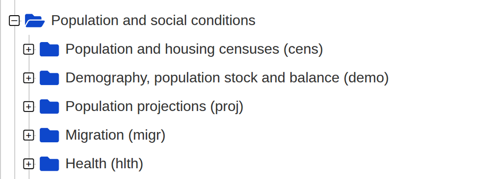

## Cada *dataset* tiene un **código**.

| Código | *Dataset* | Periodicidad |
| --- | --- | --- |
| [`une_rt_a`](https://ec.europa.eu/eurostat/databrowser/view/une_rt_a/default/table) | Desempleo por sexo y edad | anual |
| [`une_rt_m`](https://ec.europa.eu/eurostat/databrowser/view/une_rt_m/default/table) | Desempleo por sexo y edad | mensual |
| [`nama_10_pc`](https://ec.europa.eu/eurostat/databrowser/view/nama_10_pc/default/table) | PIB per cápita y sus componentes | anual |
| [`prc_hicp_manr`](https://ec.europa.eu/eurostat/databrowser/view/prc_hicp_manr/default/table) | Inflación (IPC armonizado, tasa anual) | mensual |
| [`demo_pjan`](https://ec.europa.eu/eurostat/databrowser/view/demo_pjan/default/table) | Población a 1 de enero, por edad y sexo | anual |
| [`lfst_r_lfu3rt`](https://ec.europa.eu/eurostat/databrowser/view/lfst_r_lfu3rt/default/table) | Tasa de paro por regiones (NUTS 2) | anual |

El código no es caprichoso: está hecho de trozos, separados por `_`, y cada trozo significa algo.  
Las primeras letras indican el tema y la última parte suele indicar la periodicidad (`_a` anual, `_q` trimestral, `_m` mensual). Por ejemplo:

- `une_rt_a`: `une` (*unemployment*, desempleo) + `rt` (*rate*, tasa) + `a` (*annual*, anual)
- `nama_10_pc`: `nama` (*national accounts main aggregates*, contabilidad nacional) + `10` (el sistema de cuentas SEC 2010) + `pc` (*per capita*)
- `prc_hicp_manr`: `prc` (*prices*, precios) + `hicp` (*harmonised index of consumer prices*, el IPC armonizado) + `manr` (*monthly annual rate*, la tasa anual de cada mes)
- `demo_pjan`: `demo` (*demography*, demografía) + `pjan` (*population on 1 January*, población a 1 de enero)
- `lfst_r_lfu3rt`: `lfst` (*labour force survey*, la “EPA europea”) + `r` (*regional*) + `lfu3rt` (tasa de paro)

## en un *dataset* cada dato se identifica por sus **dimensiones**. En `une_rt_a`:

```r
df <- eurostat::get_eurostat("une_rt_a")
```

| freq <chr> | age <chr> | unit <chr> | sex <chr> | geo <chr> | TIME_PERIOD <date> | values <dbl> |
| --- | --- | --- | --- | --- | --- | --- |
| A | Y15-24 | PC_ACT | F | AT | 2009-01-01 | 10.5 |
| A | Y15-24 | PC_ACT | F | AT | 2010-01-01 | 9.8 |
| A | Y15-24 | PC_ACT | F | AT | 2011-01-01 | 9.5 |
| A | Y15-24 | PC_ACT | F | AT | 2012-01-01 | 9.6 |

Primeras 4 filas de 39.909

| Dimensión | ¿Qué es? | Algunos valores |
| --- | --- | --- |
| `freq` | la periodicidad | `A` (anual) |
| `age` | el grupo de edad | `Y15-74`, `Y15-24`, `Y25-74`, … |
| `unit` | la unidad de medida | `PC_ACT` (% de la población activa) `THS_PER` (miles de personas) ❗❗ |
| `sex` | el sexo | `T` (total), `M` (hombres), `F` (mujeres) |
| `geo` | el país o la región | `ES`, `FR`, `EU27_2020`, … |
| `TIME_PERIOD` | el periodo | `2024-01-01`, `2025-01-01`, … |
| `values` | el dato | `10.5`, `9.8`, … |

En los datos solo hay códigos:  
`ES`, `PC_ACT`, `Y15-74`.  
Su significado (las “etiquetas”) está en unos diccionarios aparte, pero con el paquete `eurostat` podemos obtenerlos fácilmente

**Con la dimensión `unit` hay que tener cuidado**: en el mismo dataset, una variable suele venir en varias unidades.  
Cuidado porqué puedes mezclar porcentajes con miles de personas ❗❗

## Los códigos de los territorios

- La dimensión `geo` tiene países, agregados y regiones:

| Tipo | Códigos | Ejemplos |
| --- | --- | --- |
| países | 2 letras | `ES`, `FR`, `DE`, `IT` Ojo: Grecia es `EL` |
| agregados | letras y números | `EU27_2020` (la UE de 27 países) `EA20` (la zona euro de 20 países) |
| regiones NUTS 1 | país + 1 carácter | `ES5` (Este) |
| regiones NUTS 2 | país + 2 caracteres | `ES52` (Comunitat Valenciana) |
| regiones NUTS 3 | país + 3 caracteres | `ES523` (Valencia/València) |

**NUTS** es la clasificación europea de regiones. En España: NUTS 2 son las comunidades autónomas y NUTS 3 las provincias

**Por ejemplo**:  
`ES` (España, NUTS 0) → `ES5` (Este, NUTS 1) → `ES52` (Comunitat Valenciana, NUTS 2) → `ES523` (la provincia de Valencia, NUTS 3)

Ojo: `ES523` es la provincia, no la ciudad. Los municipios no tienen código NUTS: están en otra clasificación, las LAU (*Local Administrative Units*)

Cuidado con los agregados: si sumas o haces un ranking sin quitarlos, la “UE” aparecerá como un país más

## Tres formas de conseguir los datos

1. **Por menús**: entras en la web, buscas el *dataset*, pinchas en *Download* y guardas el fichero
2. **Con la url del fichero**: descargas el fichero desde R, sin pasar por la web
3. **Con el paquete `eurostat`**: buscas y descargas los datos desde R
- La primera forma no es reproducible; con las otras dos, el script contiene todo el proceso

Veremos primero cómo hacerlo “a mano” (formas 1 y 2) y después con el paquete `eurostat`

## Los datos, a mano

Descargar un fichero de Eurostat y limpiarlo

## Cada *dataset* tiene su página, su código … y varios formatos

- Queremos la **tasa de paro de los países europeos**. Navegando por las carpetas (*Population and social conditions* → *Labour market* → …) llegamos a la página del *dataset*, en el [*Data Browser*](https://ec.europa.eu/eurostat/databrowser/view/une_rt_a)
- Su **código** está debajo del título (*Online data code*) y al final de la url: `une_rt_a`. Apúntalo, lo vamos a necesitar!!
- Con el botón *Download* podemos bajarnos el *dataset* en varios formatos. ¿Cuál elegimos?

[figure not shown]

| Formato | ¿Cómo es? | ¿Sirve para R? |
| --- | --- | --- |
| **SDMX-CSV** | una fila por dato | sí, es el mejor |
| TSV | separado por tabuladores, con una columna por periodo | sí, pero hay que limpiarlo bastante |
| Excel (`.xlsx`) | la tabla tal como se ve en la web | con mucho trabajo |
| JSON-stat, SDMX-ML | formatos para programas | mejor con el paquete `eurostat` |

Pero … no hace falta pinchar en *Download*: la url del fichero siempre tiene la misma forma. Solo cambian el código del *dataset* y el formato:  
`https://ec.europa.eu/eurostat/api/dissemination/sdmx/2.1/data/``une_rt_a``?format=``SDMX-CSV`  
Ojo: se descarga el *dataset* completo, con todos los países, años, sexos, edades y unidades

## Descargamos el fichero SDMX-CSV … y vemos qué hay en cada dimensión

```r
my_url <- "https://ec.europa.eu/eurostat/api/dissemination/sdmx/2.1/data/une_rt_a?format=SDMX-CSV"
df_paro <- readr::read_csv(my_url)
```

**1**

Es un CSV “normal”: `read_csv()`, directamente de la url. Ha ido bien: una fila por dato, y el valor (`OBS_VALUE`) es numérico

| DATAFLOW <chr> | LAST UPDATE <chr> | freq <chr> | age <chr> | unit <chr> | sex <chr> | geo <chr> | TIME_PERIOD <dbl> | OBS_VALUE <dbl> | OBS_FLAG <chr> | CONF_STATUS <lgl> |
| --- | --- | --- | --- | --- | --- | --- | --- | --- | --- | --- |
| ESTAT:UNE_RT_A(1.0) | 10/09/26 23:00:00 | A | Y15-24 | PC_ACT | F | AT | 2009 | 10.5 | NA | NA |
| ESTAT:UNE_RT_A(1.0) | 10/09/26 23:00:00 | A | Y15-24 | PC_ACT | F | AT | 2010 | 9.8 | NA | NA |

Primeras 2 filas de 39.909

- Pero … ¿qué son `PC_ACT`, `Y15-24` y `AT`? Veamos qué valores toma cada dimensión, con `count()`:

```r
df_paro %>% count(unit)
```

| unit <chr> | n <int> |
| --- | --- |
| PC_ACT | 13303 |
| PC_POP | 13303 |
| THS_PER | 13303 |

```r
df_paro %>% count(sex)
```

| sex <chr> | n <int> |
| --- | --- |
| F | 13290 |
| M | 13308 |
| T | 13311 |

- El significado de cada código está en la web del *dataset*. También se puede descargar: cada dimensión tiene su diccionario (*codelist*), pero es más cómodo con el paquete `eurostat`, como veremos
- `OBS_FLAG` son los flags: avisos sobre un dato. Los más habituales: `b` (ruptura en la serie), `p` (provisional), `e` (estimado), `u` (poco fiable)

```r
df_paro %>% count(age)
```

| age <chr> | n <int> |
| --- | --- |
| Y15-24 | 5715 |
| Y15-29 | 5643 |
| Y15-74 | 5715 |
| Y20-64 | 5715 |
| Y25-54 | 5715 |
| Y25-74 | 5715 |
| Y55-74 | 5691 |

## Limpiamos los datos … y ya podemos usarlos

```r
df_paro <- df_paro %>%
  janitor::clean_names() %>%
  select(geo, unit, sex, age,
         anyo = time_period,
         tasa_paro = obs_value,
         flag = obs_flag) %>%
  filter(unit == "PC_ACT", sex == "T",
         age == "Y15-74") %>%
  mutate(tipo_geo = if_else(str_length(geo) == 2,
                            "país", "agregado"))
```

**1**

Nombres de columnas “cómodos”: en minúsculas y sin espacios

**2**

Solo las columnas que hacen falta, con nombres que digan qué son

**3**

Nos quedamos con una sola serie por territorio: la tasa de paro (% de la población activa), de ambos sexos, de 15 a 74 años

**4**

Los códigos de país tienen 2 letras: así separamos los países de los agregados (`EU27_2020`, `EA20`, …)

```r
df_paro %>%
  filter(geo %in% c("ES", "EU27_2020"), anyo >= 2024)
```

| geo <chr> | unit <chr> | sex <chr> | age <chr> | anyo <dbl> | tasa_paro <dbl> | flag <chr> | tipo_geo <chr> |
| --- | --- | --- | --- | --- | --- | --- | --- |
| ES | PC_ACT | T | Y15-74 | 2024 | 11.4 | d | país |
| ES | PC_ACT | T | Y15-74 | 2025 | 10.5 | d | país |
| EU27_2020 | PC_ACT | T | Y15-74 | 2024 | 6 | NA | agregado |
| EU27_2020 | PC_ACT | T | Y15-74 | 2025 | 6 | NA | agregado |

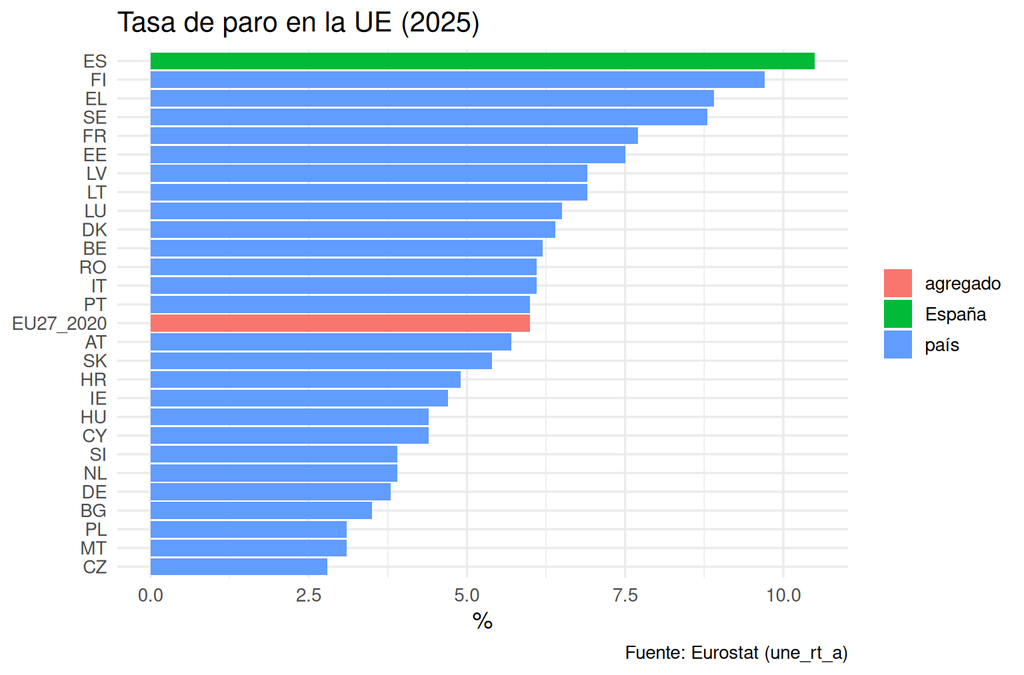

```r
df_paro %>%
  filter(anyo == max(anyo)) %>%
  #- los 27 países de la UE y el total
  filter(geo %in% c(eurostat::eu_countries$code, "EU27_2020")) %>%
  #- España, con su propio color
  mutate(tipo_geo = if_else(geo == "ES", "España", tipo_geo)) %>%
  ggplot(aes(x = tasa_paro, y = fct_reorder(geo, tasa_paro))) +
  geom_col(aes(fill = tipo_geo)) +
  labs(title = paste0("Tasa de paro en la UE (", max(df_paro$anyo), ")"),
       x = "%", y = NULL, fill = NULL, caption = "Fuente: Eurostat (une_rt_a)")
```

## Tarea: la población de los países europeos

- Tarea
- Pistas
- Solución (1-3)
- Solución (4)
- Solución (5)
- El *dataset* [`tps00001`](https://ec.europa.eu/eurostat/databrowser/view/tps00001/default/table) de Eurostat tiene la [población a 1 de enero](https://ec.europa.eu/eurostat/databrowser/view/tps00001/default/table) de los países europeos
1. Descarga desde R el fichero SDMX-CSV del *dataset* e impórtalo
2. Mira qué dimensiones tiene y qué valores toma cada una. ¿Hay algo más que países en `geo`?
3. Limpia los datos: quédate con el territorio, el año y la población, con nombres cómodos
4. ¿Cuáles son los 5 países con más población en el último año?
5. [🌶] ¿Qué 5 países han ganado más población (en %) entre el primer y el último año que hay en los datos?
- 1: la url es como la del paro, cambiando el código del *dataset*
- 2: `count()` de cada dimensión. En `geo` están también los agregados (`EU27_2020`, `EA20`, …)
- 3: `janitor::clean_names()`, `select()` y `rename()`
- 4: quédate con los países: sus códigos tienen 2 letras (`str_length(geo) == 2`)
- 5: `group_by(geo)` y `summarise()` con `first()` y `last()`

```r
my_url <- "https://ec.europa.eu/eurostat/api/dissemination/sdmx/2.1/data/tps00001?format=SDMX-CSV"

df_pob <- read_csv(my_url) %>%
  janitor::clean_names() %>%
  select(geo, anyo = time_period, poblacion = obs_value) %>%
  filter(str_length(geo) == 2)        #- solo los países
```

```r
df_pob %>%
  filter(geo == "ES") %>%
  gt::gt() %>%
  gt::fmt_number(columns = poblacion,
                 decimals = 0, sep_mark = ".")
```

| geo | anyo | poblacion |
| --- | --- | --- |
| ES | 2015 | 46.425.722 |
| ES | 2016 | 46.418.884 |
| ES | 2017 | 46.497.393 |
| ES | 2018 | 46.645.070 |
| ES | 2019 | 46.918.951 |
| ES | 2020 | 47.318.050 |
| ES | 2021 | 47.400.798 |
| ES | 2022 | 47.486.843 |
| ES | 2023 | 48.085.361 |
| ES | 2024 | 48.619.695 |
| ES | 2025 | 49.128.297 |
| ES | 2026 | 49.590.099 |

```r
df_top5 <- df_pob %>%
  filter(anyo == max(anyo)) %>%
  slice_max(poblacion, n = 5)
```

```r
df_top5 %>%
  gt::gt() %>%
  gt::fmt_number(columns = poblacion,
                 decimals = 0, sep_mark = ".")
```

| geo | anyo | poblacion |
| --- | --- | --- |
| DE | 2026 | 83.467.117 |
| UK | 2026 | 69.554.275 |
| FR | 2026 | 69.112.309 |
| IT | 2026 | 58.942.828 |
| ES | 2026 | 49.590.099 |

```r
df_crec <- df_pob %>%
  filter(!is.na(poblacion)) %>%
  group_by(geo) %>%
  summarise(anyo_ini = min(anyo), anyo_fin = max(anyo),
            pob_ini  = first(poblacion, order_by = anyo),
            pob_fin  = last(poblacion, order_by = anyo)) %>%
  mutate(crec = pob_fin / pob_ini - 1) %>%
  arrange(desc(crec))
```

```r
df_crec %>%
  filter(geo %in% c("DE", "UK", "FR", "IT", "ES") |
         crec %in% range(crec)) %>%
  gt::gt() %>%
  gt::fmt_number(columns = c(pob_ini, pob_fin),
                 decimals = 0, sep_mark = ".") %>%
  gt::fmt_percent(columns = crec, decimals = 1)
```

**1**

`range(crec)` devuelve el mínimo y el máximo de `crec`: así nos quedamos también con el país que más crece y con el que menos

| geo | anyo_ini | anyo_fin | pob_ini | pob_fin | crec |
| --- | --- | --- | --- | --- | --- |
| MT | 2015 | 2026 | 438.805 | 588.254 | 34.1% |
| UK | 2015 | 2026 | 64.852.826 | 69.554.275 | 7.2% |
| ES | 2015 | 2026 | 46.425.722 | 49.590.099 | 6.8% |
| FR | 2015 | 2026 | 66.458.153 | 69.112.309 | 4.0% |
| DE | 2015 | 2026 | 81.197.537 | 83.467.117 | 2.8% |
| IT | 2015 | 2026 | 60.295.497 | 58.942.828 | −2.2% |
| MD | 2015 | 2026 | 3.555.159 | 2.365.645 | −33.5% |

## El paquete *eurostat*

Los datos de Eurostat, directamente desde R

## [`eurostat`](https://ropengov.github.io/eurostat/) es un paquete de [rOpenGov](https://ropengov.org/) para descargar datos de Eurostat

- Ventajas frente a descargar ficheros:
  - puedes buscar *datasets* desde R
  - los datos llegan ya limpios: una fila por dato, con fechas de verdad
  - puedes pedir solo una parte del *dataset*
  - tiene los diccionarios: convierte los códigos en etiquetas con una función
  - guarda una copia (*caché*) de lo que descargas: la segunda vez es inmediato
- Tiene una [*cheatsheet*](https://raw.githubusercontent.com/rstudio/cheatsheets/main/eurostat.pdf) y unos [tutoriales](https://ropengov.github.io/eurostat/articles/) muy buenos

| Para … | función |
| --- | --- |
| buscar *datasets* | `search_eurostat()` |
| ver el índice de toda la base de datos | `get_eurostat_toc()` |
| **descargar un *dataset*** | **`get_eurostat()`** |
| cambiar los códigos por sus etiquetas | `label_eurostat()` |
| ver el diccionario de una dimensión | `get_eurostat_dic()` |
| descargar los mapas de países y regiones | `get_eurostat_geospatial()` |

**El recorrido habitual**: buscar → descargar → (elegir unidades y categorías) → etiquetar

Si ya conoces el código del *dataset*, puedes ir directamente a `get_eurostat()`

## Paso 1: buscar un *dataset*

```r
aa <- search_eurostat("unemployment")

aa %>% select(title, code, data.start, data.end) %>% slice(1:3)
```

**1**

Busca en los títulos de los *datasets*. Hay que buscar en inglés (o en francés o alemán, con `lang`)

**2**

Salen 55 *datasets*: lo mejor es guardar el resultado y mirarlo con calma (`View(aa)`)

| title <chr> | code <chr> | data.start <chr> | data.end <chr> |
| --- | --- | --- | --- |
| Persons in long-term unemployment (12 months or more) by educational attainment level and NUTS 2 region | lfst_r_lfu2ltu | 1999 | 2025 |
| Regional disparities in unemployment rates (NUTS level 2, NUTS level 3) | lfst_r_lmdur | 1999 | 2025 |
| Regional disparities in long-term unemployment rates (NUTS level 2) | lfst_r_lmdltu | 1999 | 2025 |

- Se puede afinar con `filter()`:

```r
aa %>% filter(str_detect(title, "annual data")) %>% select(title, code, data.start, data.end)
```

| title <chr> | code <chr> | data.start <chr> | data.end <chr> |
| --- | --- | --- | --- |
| Long-term unemployment by sex - annual data (1996–2020) | une_ltu_a_h | 1996 | 2020 |
| Supplementary indicators to unemployment - annual data (1992–2020) | lfsi_sup_a_h | 1992 | 2020 |
| Long-term unemployment by sex - annual data | une_ltu_a | 2003 | 2025 |
| Supplementary indicators to unemployment - annual data | lfsi_sup_a | 2003 | 2025 |
| Long-term unemployment by sex - annual data | une_ltu_a | 2003 | 2025 |
| Long-term unemployment by sex - annual data | une_ltu_a | 2003 | 2025 |

## Paso 2: descargar el *dataset*

```r
df <- get_eurostat("une_rt_a")

df
```

| freq <chr> | age <chr> | unit <chr> | sex <chr> | geo <chr> | TIME_PERIOD <date> | values <dbl> |
| --- | --- | --- | --- | --- | --- | --- |
| A | Y15-24 | PC_ACT | F | AT | 2009-01-01 | 10.5 |
| A | Y15-24 | PC_ACT | F | AT | 2010-01-01 | 9.8 |
| A | Y15-24 | PC_ACT | F | AT | 2011-01-01 | 9.5 |
| A | Y15-24 | PC_ACT | F | AT | 2012-01-01 | 9.6 |
| A | Y15-24 | PC_ACT | F | AT | 2013-01-01 | 10.4 |
| A | Y15-24 | PC_ACT | F | AT | 2014-01-01 | 10.4 |

Primeras 6 filas de 39.909

- Llega ya limpio: una fila por dato, y los valores (`values`) son numéricos
- `TIME_PERIOD` es una fecha de verdad: el primer día del periodo. Si lo prefieres como número (`2024`), `get_eurostat("une_rt_a", time_format = "num")`
- Por defecto no trae los flags. Para tenerlos: `get_eurostat("une_rt_a", keepFlags = TRUE)`. Los que más importan son `b` (*break in time series*: ese año cambió la forma de medir, y el dato no es comparable con los anteriores) y `d` (*definition differs*: la definición no es exactamente la estándar)
- Pero siguen siendo códigos …

## Paso 3: de códigos a etiquetas

```r
df_l <- label_eurostat(df)

df_l %>% slice(1:3)
```

| freq <chr> | age <chr> | unit <chr> | sex <chr> | geo <chr> | TIME_PERIOD <date> | values <dbl> |
| --- | --- | --- | --- | --- | --- | --- |
| Annual | From 15 to 24 years | Percentage of population in the labour force | Females | Austria | 2009-01-01 | 10.5 |
| Annual | From 15 to 24 years | Percentage of population in the labour force | Females | Austria | 2010-01-01 | 9.8 |
| Annual | From 15 to 24 years | Percentage of population in the labour force | Females | Austria | 2011-01-01 | 9.5 |

- Ahora se entiende, pero para filtrar es más cómodo (y más seguro) usar los códigos. Lo mejor es tener las dos cosas: con `code` se indica de qué dimensiones conservar el código

```r
df_l <- label_eurostat(df, code = c("geo", "unit", "sex", "age"))

df_l %>%
  select(geo_code, geo, unit_code, unit, sex_code, sex, age_code, age, TIME_PERIOD, values) %>%
  slice(1:3)
```

| geo_code <chr> | geo <chr> | unit_code <chr> | unit <chr> | sex_code <chr> | sex <chr> | age_code <chr> | age <chr> | TIME_PERIOD <date> | values <dbl> |
| --- | --- | --- | --- | --- | --- | --- | --- | --- | --- |
| AT | Austria | PC_ACT | Percentage of population in the labour force | F | Females | Y15-24 | From 15 to 24 years | 2009-01-01 | 10.5 |
| AT | Austria | PC_ACT | Percentage of population in the labour force | F | Females | Y15-24 | From 15 to 24 years | 2010-01-01 | 9.8 |
| AT | Austria | PC_ACT | Percentage of population in the labour force | F | Females | Y15-24 | From 15 to 24 years | 2011-01-01 | 9.5 |

## Los diccionarios

- ¿Qué significa un código? ¿Qué códigos hay? `get_eurostat_dic()` devuelve el diccionario de una dimensión:

```r
aa <- get_eurostat_dic("geo")
aa <- get_eurostat_dic("unit")
aa <- get_eurostat_dic("age")
aa <- get_eurostat_dic("sex")
aa <- get_eurostat_dic("freq")
```

| dimensión | filas |
| --- | --- |
| geo | 4.292 |
| unit | 773 |
| age | 686 |
| sex | 8 |
| freq | 12 |

- Los diccionarios son de todo Eurostat, no solo de nuestro *dataset*: por eso el de `sex` tiene 8 filas, aunque en `une_rt_a` solo salen 3
- Si ya tienes `df_l` (con los códigos y las etiquetas), con `distinct()` ves las parejas código-etiqueta de cada dimensión:

```r
df_l %>% distinct(unit_code, unit)
```

| unit_code <chr> | unit <chr> |
| --- | --- |
| PC_ACT | Percentage of population in the labour force |
| PC_POP | Percentage of total population |
| THS_PER | Thousand persons |

```r
df_l %>% distinct(sex_code, sex)
```

| sex_code <chr> | sex <chr> |
| --- | --- |
| F | Females |
| M | Males |
| T | Total |

- Y el paquete trae listas de países ya preparadas: `eu_countries`, `ea_countries`, `efta_countries`, …

## `filters`: descargar solo una parte … y el paro en España y en Europa

- Con `filters` se descarga solo lo que se necesita: una lista con los códigos de cada dimensión

```r
df_5 <- get_eurostat("une_rt_a",
          filters = list(
            geo  = c("ES", "FR", "IT", "DE",
                     "EU27_2020"),
            sex  = "T",
            age  = "Y15-74",
            unit = "PC_ACT"))

df_5 %>% filter(geo == "ES", time >= "2024-01-01")
```

**1**

Las dimensiones que no se mencionan se descargan enteras

| freq <chr> | age <chr> | unit <chr> | sex <chr> | geo <chr> | time <date> | values <dbl> |
| --- | --- | --- | --- | --- | --- | --- |
| A | Y15-74 | PC_ACT | T | ES | 2024-01-01 | 11.4 |
| A | Y15-74 | PC_ACT | T | ES | 2025-01-01 | 10.5 |

- ¡Atención! Con `filters` la columna del tiempo se llama `time` (sin `filters`, `TIME_PERIOD`): los datos se piden a otra API de Eurostat
- Para el tiempo: `time = 2024` (un año), `sinceTimePeriod = 2015` (desde un año) o `lastTimePeriod = 5` (los últimos periodos)

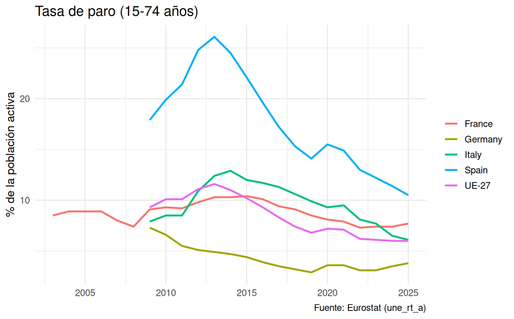

```r
df_5 %>%
  label_eurostat(code = "geo") %>%
  mutate(geo = if_else(geo_code == "EU27_2020",
                       "UE-27", geo)) %>%
  ggplot(aes(x = time, y = values, color = geo)) +
  geom_line(linewidth = 1) +
  labs(title = "Tasa de paro (15-74 años)", color = NULL,
       x = NULL, y = "% de la población activa",
       caption = "Fuente: Eurostat (une_rt_a)")
```

## Trampas y cosas a tener en cuenta

- En los datos
- Con el paquete

| Trampa | Ejemplo | Solución |
| --- | --- | --- |
| en los datos solo hay códigos | `PC_ACT`, `Y15-74`, `B1GQ` | mirar su significado (o `label_eurostat()`) |
| la misma variable en varias unidades | `PC_ACT`, `PC_POP`, `THS_PER` | `filter(unit == ...)`: así que cuidado!! |
| los totales están mezclados con las categorías | `sex == "T"`, `age == "TOTAL"` | `filter()`: cuidado al sumar |
| países y agregados juntos | `ES`, `EU27_2020`, `EA20` | separarlos por la longitud del código |
| los códigos de algunos países no son los habituales | Grecia es `EL` (no `GR`) | `eurostat::eu_countries` |
| datos con avisos | flags `b`, `p`, `e`, `u` | mirar la columna de flags |
| el *dataset* completo puede ser enorme | millones de filas | descargar solo una parte (con el paquete) |

Después de importar, haz un `count()` de cada dimensión. Siempre

- **La caché**: `get_eurostat()` guarda lo que descarga, y la próxima vez lo lee del disco. Si quieres los datos actualizados: `get_eurostat(..., update_cache = TRUE)`
- **Los códigos cambian**: la UE era `EU28` y ahora es `EU27_2020`; la zona euro pasó de `EA19` a `EA20` al entrar Croacia. Y hay *datasets* que se dejan de actualizar y se sustituyen por otros
- **Las regiones también**: la clasificación NUTS se revisa cada pocos años. Si al unir datos y mapas se pierden regiones, mira qué versión usa cada uno
- **Datos anuales, trimestrales y mensuales** suelen están en *datasets* distintos (`une_rt_a`, `une_rt_q`, `une_rt_m`)
- **Todo está en inglés**: los títulos y las etiquetas (también en francés y alemán, con `lang`)

Guarda en disco los datos que uses en un trabajo (`rio::export()`): Eurostat revisa los datos, y mañana pueden ser otros

## Tarea: ¿qué países son más ricos?

- Tarea
- Pistas
- Solución (1)
- Solución (2-4)
- Solución (5)
- El *dataset* [`nama_10_pc`](https://ec.europa.eu/eurostat/databrowser/view/nama_10_pc/default/table) tiene el PIB per cápita de los países europeos
1. Descarga el *dataset* y mira qué dimensiones tiene. ¿Cuántas unidades de medida (`unit`) hay? ¿Y cuántas magnitudes (`na_item`)?
2. Quédate con el PIB (`na_item`: `B1GQ`) en paridad de poder de compra (`unit`: `CP_PPS_EU27_2020_HAB`) del año 2024
3. Quédate solo con los países de la UE y añade su nombre
4. Ordena los países de mayor a menor PIB per cápita. ¿En qué puesto está España?
5. [🌶] Haz un gráfico de barras, destacando a España
- 1: `count(unit)` y `count(na_item)`. Para saber qué significan: `get_eurostat_dic("na_item")`
- 2: `filter()`; o, mejor, descargar solo eso con `filters`
- 3: `filter(geo %in% eu_countries$code)` y `label_eurostat(code = "geo")`
- 4: `arrange(desc(values))` y `mutate(ranking = row_number())`
- 5: `geom_col(aes(fill = geo_code == "ES"))`

```r
df_pib <- get_eurostat("nama_10_pc")

df_pib %>%
  label_eurostat(code = "na_item") %>%
  distinct(na_item_code, na_item)
```

| na_item_code <chr> | na_item <chr> |
| --- | --- |
| B1GQ | Gross domestic product at market prices |
| P3 | Final consumption expenditure |
| P31_S13 | Individual consumption expenditure of general government |
| P31_S14 | Final consumption expenditure of household |
| P31_S14_S15 | Household and NPISH final consumption expenditure |
| P31_S15 | Final consumption expenditure of NPISH |
| P32_S13 | Collective consumption expenditure of general government |
| P3_S13 | Final consumption expenditure of general government |
| P41 | Actual individual consumption |

```r
df_pib %>%
  label_eurostat(code = "unit") %>%
  distinct(unit_code, unit)
```

| unit_code <chr> | unit <chr> |
| --- | --- |
| CLV10_EUR_HAB | Chain linked volumes (2010), euro per capita |
| CLV15_EUR_HAB | Chain linked volumes (2015), euro per capita |
| CLV20_EUR_HAB | Chain linked volumes (2020), euro per capita |

Primeras 3 filas de 12

- Hay 12 unidades de medida y 9 magnitudes. ¡No se puede usar sin filtrar!

```r
df_pib <- get_eurostat("nama_10_pc",
                       filters = list(na_item = "B1GQ", unit = "CP_PPS_EU27_2020_HAB",
                                      time = 2024)) %>%
  filter(geo %in% eu_countries$code) %>%
  label_eurostat(code = "geo") %>%
  select(geo_code, pais = geo, pib_pc = values) %>%
  arrange(desc(pib_pc)) %>%
  mutate(ranking = row_number())
```

**1**

Descargamos solo el PIB (`B1GQ`), por habitante y en paridad de poder de compra (`CP_PPS_EU27_2020_HAB`), del año 2024

**2**

Nos quedamos con los 27 países de la UE

**3**

Añadimos el nombre de cada país (y mantenemos su código en `geo_code`)

**4**

Ordenamos de mayor a menor PIB per cápita y numeramos el puesto de cada país

```r
df_pib %>%
  filter(ranking <= 3 | geo_code == "ES") %>%
  gt::gt() %>%
  gt::fmt_number(columns = pib_pc,
                 decimals = 0, sep_mark = ".")
```

| geo_code | pais | pib_pc | ranking |
| --- | --- | --- | --- |
| LU | Luxembourg | 98.982 | 1 |
| IE | Ireland | 88.343 | 2 |
| NL | Netherlands | 53.149 | 3 |
| ES | Spain | 36.497 | 14 |

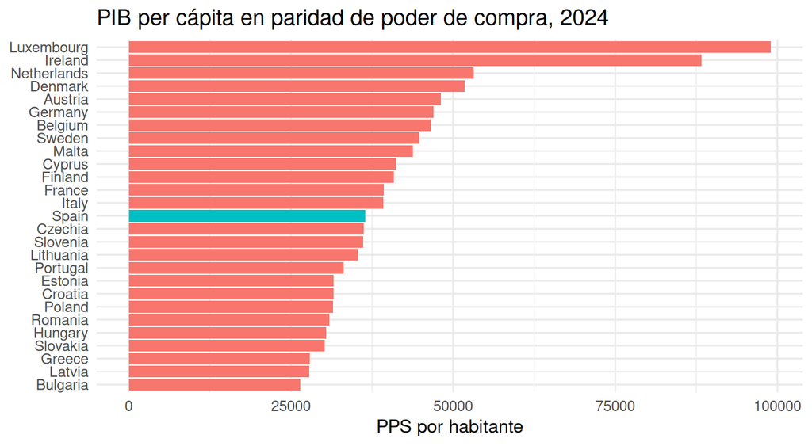

```r
df_pib %>%
  ggplot(aes(x = pib_pc, y = fct_reorder(pais, pib_pc))) +
  geom_col(aes(fill = geo_code == "ES"), show.legend = FALSE) +
  labs(title = "PIB per cápita en paridad de poder de compra, 2024", x = "PPS por habitante", y = NULL)
```

## Tarea: el paro en las comunidades autónomas

- Tarea
- Pistas
- Solución (1-2)
- Solución (3)
- Solución (4)
- Con el *dataset* [`lfst_r_lfu3rt`](https://ec.europa.eu/eurostat/databrowser/view/lfst_r_lfu3rt/default/table) (tasa de paro por regiones NUTS 2):
1. Descarga la tasa de paro total (`sex`: `T`; `age`: `Y15-74`; `isced11`: `TOTAL`) desde 2015
2. Quédate con las regiones NUTS 2 de España (las comunidades autónomas) y añade su nombre
3. ¿Qué 3 comunidades tenían la tasa de paro más alta en el último año? ¿Y la más baja?
4. [🌶] Dibuja la evolución de la tasa de paro en la Comunitat Valenciana, en España y en la UE
- 1: `filters = list(..., sinceTimePeriod = 2015)`
- 2: las CCAA tienen códigos de 4 caracteres que empiezan por `ES`: `str_detect(geo, "^ES")` y `str_length(geo) == 4`
- 3: `filter(time == max(time))`, `slice_max()` y `slice_min()`
- 4: los códigos son `ES52`, `ES` y `EU27_2020`

```r
df_reg <- get_eurostat("lfst_r_lfu3rt",
                       filters = list(sex = "T", age = "Y15-74", isced11 = "TOTAL",
                                      sinceTimePeriod = 2015))

df_ccaa <- df_reg %>%
  filter(str_detect(geo, "^ES"), str_length(geo) == 4) %>%
  label_eurostat(code = "geo", fix_duplicated = TRUE) %>%
  select(geo_code, ccaa = geo, time, tasa_paro = values)
```

**1**

Descargamos solo la tasa de paro total: ambos sexos, de 15 a 74 años y todos los niveles de estudios, desde 2015

**2**

Las comunidades autónomas: los códigos que empiezan por `ES` y tienen 4 caracteres (NUTS 2)

**3**

Añadimos el nombre de cada comunidad. `fix_duplicated = TRUE` evita problemas si dos regiones se llaman igual

```r
df_ccaa %>% slice(1:3)
```

| geo_code <chr> | ccaa <chr> | time <date> | tasa_paro <dbl> |
| --- | --- | --- | --- |
| ES11 | Galicia | 2015-01-01 | 19.3 |
| ES11 | Galicia | 2016-01-01 | 17.2 |
| ES11 | Galicia | 2017-01-01 | 15.7 |

```r
df_ccaa %>%
  filter(time == max(time)) %>%
  slice_max(tasa_paro, n = 3)
```

| geo_code <chr> | ccaa <chr> | time <date> | tasa_paro <dbl> |
| --- | --- | --- | --- |
| ES64 | Ciudad de Melilla | 2025-01-01 | 24.9 |
| ES63 | Ciudad de Ceuta | 2025-01-01 | 24.3 |
| ES61 | Andalucía | 2025-01-01 | 15.2 |

```r
df_ccaa %>%
  filter(time == max(time)) %>%
  slice_min(tasa_paro, n = 3)
```

| geo_code <chr> | ccaa <chr> | time <date> | tasa_paro <dbl> |
| --- | --- | --- | --- |
| ES13 | Cantabria | 2025-01-01 | 7.3 |
| ES21 | País Vasco | 2025-01-01 | 7.3 |
| ES22 | Comunidad Foral de Navarra | 2025-01-01 | 7.7 |

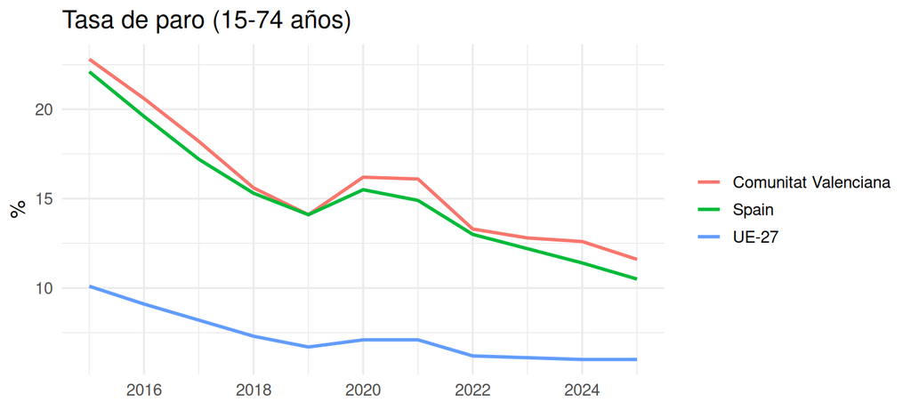

```r
df_reg %>%
  filter(geo %in% c("ES52", "ES", "EU27_2020")) %>%
  label_eurostat(code = "geo") %>%
  mutate(geo = if_else(geo_code == "EU27_2020", "UE-27", geo)) %>%
  ggplot(aes(x = time, y = values, color = geo)) +
  geom_line(linewidth = 1) +
  labs(title = "Tasa de paro (15-74 años)", x = NULL, y = "%", color = NULL)
```

## Ejemplo: un mapa de las regiones europeas

- Para un mapa hacen falta dos cosas: los datos y las “formas” (geometrías) de las regiones. El paquete `eurostat` consigue las dos

```r
df_reg <- get_eurostat("lfst_r_lfu3rt",
            filters = list(sex = "T", age = "Y15-74",
                           isced11 = "TOTAL",
                           time = 2024))

geo_nuts2 <- get_eurostat_geospatial(
               resolution = "20", nuts_level = "2",
               year = 2024)

df_mapa <- geo_nuts2 %>%
  left_join(df_reg, by = "geo")
```

**1**

Los datos: la tasa de paro por regiones (NUTS 2), de 2024

**2**

Las geometrías de las regiones NUTS 2, en su versión de 2024 (la que usan los datos). Necesita los paquetes `sf` y `giscoR`

**3**

Se unen por el código de la región, que en los dos sitios se llama `geo`

- `df_mapa` es un data.frame “con geometría” (un objeto `sf`): tiene 299 filas, una por región, y se dibuja con `geom_sf()`. Lo vemos con más calma en las slides de mapas

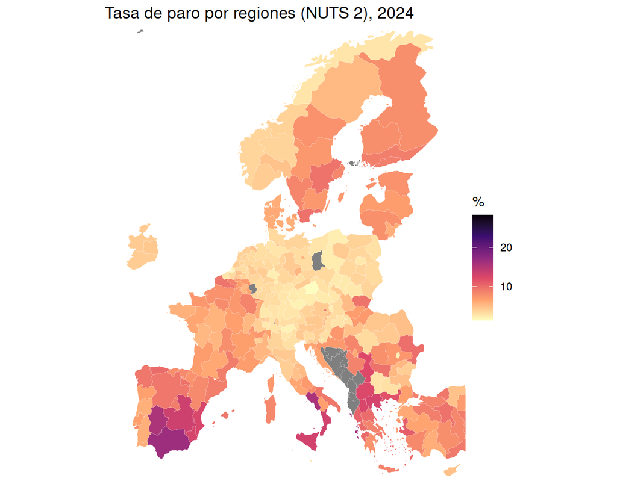

```r
ggplot(df_mapa) +
  geom_sf(aes(fill = values), color = "white",
          linewidth = 0.05) +
  #- "zoom" a Europa:
  coord_sf(xlim = c(-11, 33), ylim = c(35, 70)) +
  scale_fill_viridis_c(option = "magma", direction = -1) +
  labs(title = "Tasa de paro por regiones (NUTS 2), 2024",
       fill = "%") +
  theme_void()
```

## … y cómo ha cambiado: un mapa por año

- Pedimos varios años en `filters` y hacemos un mapa por año con `facet_wrap()`

```r
df_reg4 <- get_eurostat("lfst_r_lfu3rt",
  filters = list(sex = "T", age = "Y15-74",
                 isced11 = "TOTAL",
                 time = c(2012, 2016, 2020, 2024)))

df_mapa4 <- geo_nuts2 %>%
  inner_join(df_reg4, by = "geo") %>%
  mutate(anyo = year(time))
```

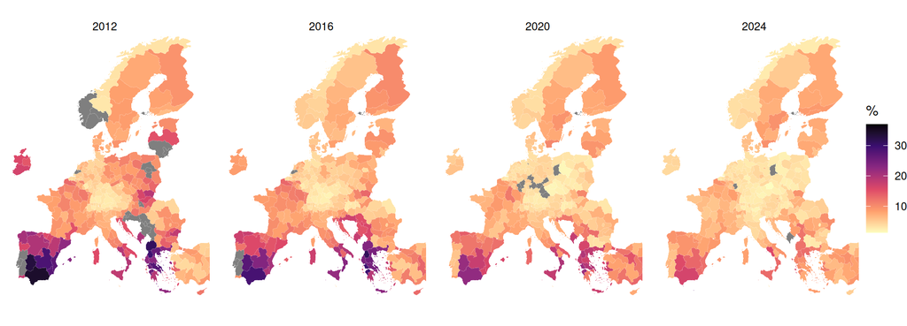

```r
ggplot(df_mapa4) +
  geom_sf(aes(fill = values), color = "white",
          linewidth = 0.03) +
  coord_sf(xlim = c(-11, 33), ylim = c(35, 70)) +
  scale_fill_viridis_c(option = "magma", direction = -1) +
  facet_wrap(vars(anyo), nrow = 1) +
  labs(fill = "%") +
  theme_void()
```

- En gris, las regiones sin dato ese año: las geometrías son las de 2024, y algunas regiones han cambiado de código desde entonces

## Para saber más

- La [web del paquete `eurostat`](https://ropengov.github.io/eurostat/), con sus [tutoriales](https://ropengov.github.io/eurostat/articles/), y su [*cheatsheet*](https://raw.githubusercontent.com/rstudio/cheatsheets/main/eurostat.pdf)
- La [base de datos](https://ec.europa.eu/eurostat/web/main/data/database) de Eurostat y su [*Data Browser*](https://ec.europa.eu/eurostat/databrowser/)
- [*Statistics Explained*](https://ec.europa.eu/eurostat/statistics-explained/): artículos de Eurostat que explican cada estadística, con sus definiciones
- La clasificación de regiones [NUTS](https://ec.europa.eu/eurostat/web/nuts)
- Para datos de España con más detalle: las slides sobre los datos del INE
- Para mapas: las slides de mapas con R

## Resumen

| Para … | usamos … |
| --- | --- |
| encontrar un *dataset* | la [base de datos](https://ec.europa.eu/eurostat/web/main/data/database) de Eurostat, o `search_eurostat()` |
| descargar su fichero a mano | `https://ec.europa.eu/eurostat/api/dissemination/sdmx/2.1/data/`*código*`?format=SDMX-CSV` |
| importarlo | `read_csv(url)` |
| saber qué contiene | `count()` de cada dimensión |
| descargarlo con el paquete | `get_eurostat("código")` |
| … solo una parte | `get_eurostat("código", filters = list(...))` |
| … con los flags | `keepFlags = TRUE` |
| cambiar códigos por etiquetas | `label_eurostat(df, code = "geo")` |
| ver un diccionario | `get_eurostat_dic("unit")` |
| quedarse con los países de la UE | `filter(geo %in% eu_countries$code)` |
| hacer un mapa | `get_eurostat_geospatial()` + `left_join()` + `geom_sf()` |